# MOFAmodel Factor2 - under the hood

### Introduction

To look “under the hood” of Factor 2, we need to pull the feature weights (loadings) for both the RNA and Protein views. In MOFA2, a high absolute weight indicates that the feature is a strong driver of the variation captured by that factor.

Positive weights mean the gene/protein is upregulated in Factor 2 High (the high-risk/Basal-like group), while negative weights mean it’s upregulated in Factor 2 Low (the low-risk/Classical group). Factor 2 High and Low were defined in the previous notebook `survival_analysis.rmd` based on the median Factor 2 value across samples.

### Load MOFA model RNA and proteome data

```r
# Load the MOFA model (Results is at project root, one level up from src/)
model_path <- here("..", "Results", "MOFA_models", "mofa_cptac_pdac_rna_proteome_model.hdf5")
MOFAmodel <- load_model(model_path)
summary(MOFAmodel)
```

```
## Length  Class   Mode
##      1   MOFA     S4
```

### Extract Factor 2 loadings for RNA and Proteome

```r
# Get the weights (loadings) for Factor 2
factor_index <- 2

# Extract weights for Factor 2 across all views
weights <- get_weights(MOFAmodel, factors = factor_index, as.data.frame = TRUE)

# Separate and sort the top 50 for RNA and Protein
top_rna <- weights %>%
  filter(view == "RNA") %>%
  arrange(desc(abs(value))) %>%
  head(50)

top_protein <- weights %>%
  filter(view == "Protein") %>%
  arrange(desc(abs(value))) %>%
  head(50)
```

### Plot distribution of Factor 2 weights

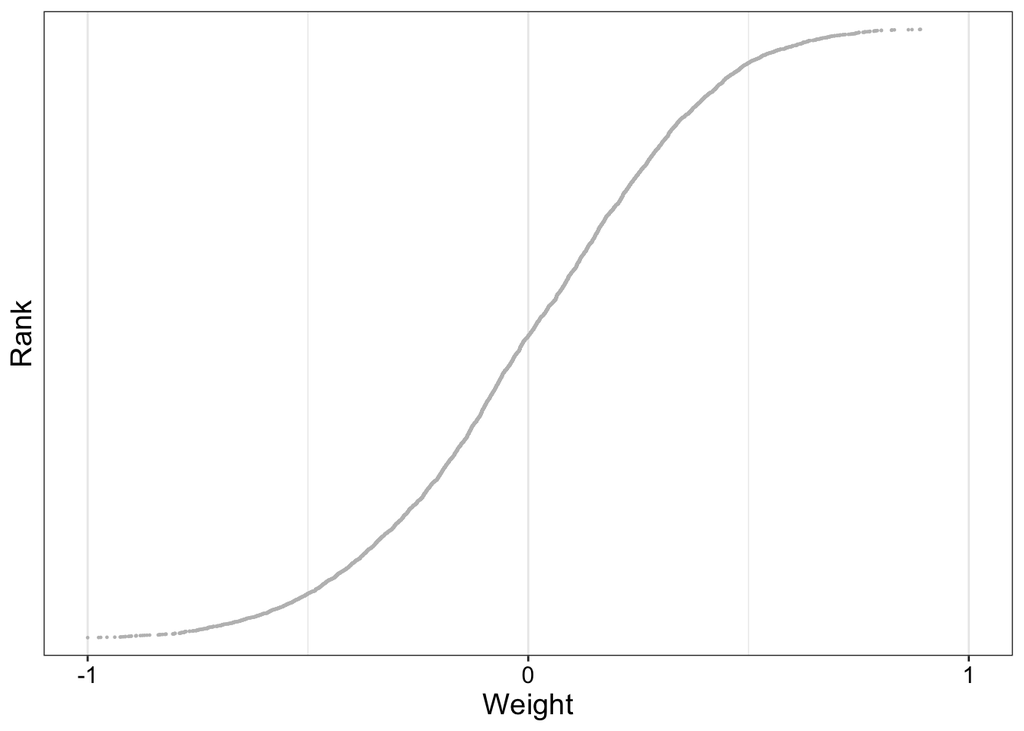

```r
# Plot the full distribution of weights for Factor 2
# 'scale = TRUE' to see them on a relative -1 to 1 scale
plot_weights(MOFAmodel,
             view = "Protein",
             factor = 2,
             nfeatures = 0, # Show all features
             scale = TRUE)
```

### Plot top 50 Protein weights using MOFA2 built-in function

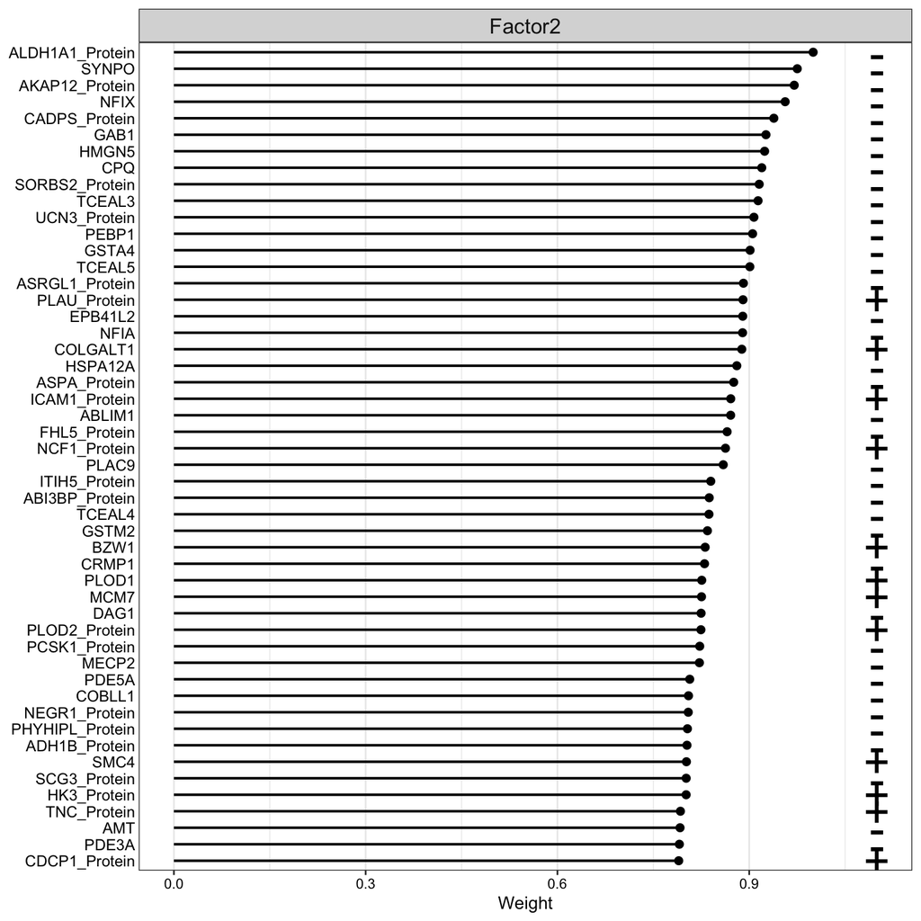

```r
plot_top_weights(MOFAmodel,
                 view = "Protein",
                 factor = 2,
                 nfeatures = 50, # Top 50 features
                 scale = TRUE)
```

### Plot for the Protein weights (the likely “survival engine”)

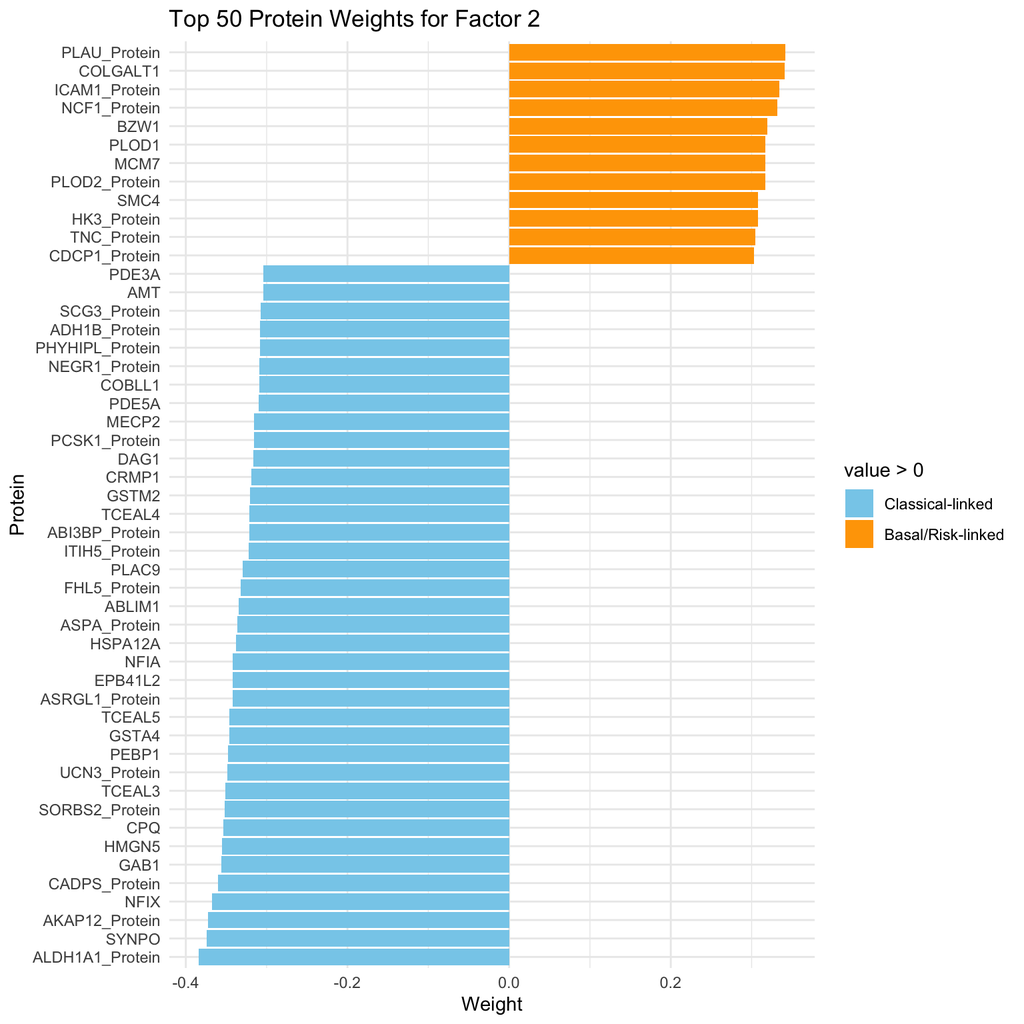

```r
ggplot(top_protein, aes(x = reorder(feature, value), y = value, fill = value > 0)) +
  geom_bar(stat = "identity") +
  coord_flip() +
  scale_fill_manual(values = c("skyblue", "orange"), labels = c("Classical-linked", "Basal/Risk-linked")) +
  labs(title = "Top 50 Protein Weights for Factor 2", x = "Protein", y = "Weight") +
  theme_minimal()
```

## Biological Summary of MOFA2 Factor 2

Factor 2 represents a profound molecular pivot between a differentiated, metabolically active “Classical” state and an aggressive, “Basal-like” state defined by mechanical remodeling.

### High-Risk (Basal-like) Program

The high-risk (positive weight) side of the factor is dominated by a coordinated extracellular matrix (ECM) assembly line. It is not merely expressing collagen; it is expressing the specialized machinery required to physically modify and stiffen it. Proteins like **PLOD1/2** and **COLGALT1** are critical for collagen hydroxylation and glycosylation, processes that increase stromal stiffness and promote tumor cell mechanotransduction and invasion [1, 2]. This “stiff” stroma acts as both a physical barrier to chemotherapy and a scaffold for metastasis, explaining why this proteomic signature is a more robust survival predictor than transcriptomic staging alone [3].

The presence of **PLAU** (Urokinase) and **TNC** (Tenascin-C) further defines the invasive phenotype. PLAU is a key protease that degrades the basement membrane, while Tenascin-C is often enriched at the “invasive front” of PDAC, where it promotes an epithelial-to-mesenchymal transition (EMT) and creates a survival niche for aggressive clones [4, 5]. Furthermore, the high loading of **CDCP1** (CUB Domain-Containing Protein 1) links Factor 2 to a known “Squamous” master regulator that integrates hypoxia and TGF-$\beta$ signaling to drive gemcitabine resistance [6].

### Low-Risk (Classical) Program

**Effectively, Factor 2 captures the loss of ductal identity and the gain of a mechanical, invasive program.**

### References

1. Tian, C., et al. (2021). “PLOD2-mediated collagen cross-linking promotes metastasis in head and neck squamous cell carcinoma and is a potential therapeutic target.” *Theranostics*. (Relevant to the role of PLOD family in mechanical stiffness).
2. Chen, Y., et al. (2018). “Lysyl hydroxylase 2 (PLOD2) promotes TGF-$\beta$-induced EMT and metastasis in pancreatic cancer.” *Biochemical and Biophysical Research Communications*.
3. Cao, L., et al. (2021). “Proteogenomic characterization of pancreatic ductal adenocarcinoma.” *Cell*. (The primary CPTAC-PDA study confirming the discrepancy between RNA and Protein signatures).
4. Moffitt, R. A., et al. (2015). “Virtual microdissection retains clinical and molecular subtypes of pancreatic cancer.” *Nature Genetics*. (Defining the original Classical vs. Basal-like/Squamous gradient).
5. Esposito, I., et al. (2006). “Tenascin-C and annexin II expression in the process of pancreatic carcinogenesis.” *Journal of Pathology*.
6. Uekita, T., et al. (2014). “CDCP1 promotes metastasis by somatic-cell-like hyper-migration in pancreatic cancer.” *Scientific Reports*.
7. Kim, J., et al. (2019). “ALDH1A1 contributes to lineage differentiation and is a marker of better prognosis in specific PDAC subsets.” *Oncology Letters*.
8. Min, J. N., et al. (2009). “HSPA12A essential for maintaining cellular homeostasis under metabolic stress.” *Journal of Biological Chemistry*.